# 161.777 Practical Data Mining

Project 2025

Siddharthan Muthukumaran

```r
library(tidyverse)
library(arules)
```

```r
# Read in the data
ice.train <- read_csv("https://www.massey.ac.nz/~jcmarsha/161777/assessment/data/ice-train.csv")
ice.test  <- read_csv("https://www.massey.ac.nz/~jcmarsha/161777/assessment/data/ice-test.csv")
campy.train <- read_csv("https://www.massey.ac.nz/~jcmarsha/161777/assessment/data/campy-train.csv") |>
  mutate(Source = factor(Source))
campy.test  <- read_csv("https://www.massey.ac.nz/~jcmarsha/161777/assessment/data/campy-test.csv")
wv_survey <- read_csv("https://www.massey.ac.nz/~jcmarsha/161777/assessment/data/wv_survey2014.csv")
flags <- read.transactions("https://www.massey.ac.nz/~jcmarsha/161777/assessment/data/flags.txt", cols=1)
```

## Exercise 1: Predicting ice thickness

```r
library(tidyverse)
library(rpart)
library(Metrics)
# Load the data
ice.train <- read_csv("ice-train.csv")
ice.test <- read_csv("ice-test.csv")
# Check column names
colnames(ice.train)
```

```
##  [1] "Year"      "MinDay"    "MaxDay"    "MinLat"    "MaxLat"    "MinLon"
##  [7] "MaxLon"    "Length"    "Nsamps"    "Thickness"
```

```r
colnames(ice.test)
```

```
## [1] "Year"   "MinDay" "MaxDay" "MinLat" "MaxLat" "MinLon" "MaxLon" "Length"
## [9] "Nsamps"
```

```r
# Fit Linear Regression Model
lm.model <- lm(Thickness ~ ., data = ice.train)

# Fit Regression Tree Model
tree.model <- rpart(Thickness ~ ., data = ice.train)

# Predict on training data (since test set doesn't have Thickness)
lm.train.pred <- predict(lm.model, newdata = ice.train)
tree.train.pred <- predict(tree.model, newdata = ice.train)

# Calculate RMSE on training data
lm.train.rmse <- rmse(ice.train$Thickness, lm.train.pred)
tree.train.rmse <- rmse(ice.train$Thickness, tree.train.pred)

# Output RMSEs
lm.train.rmse
```

```
## [1] 0.8523328
```

```r
tree.train.rmse
```

```
## [1] 0.5879889
```

```r
ice.test$.pred <- predict(tree.model, newdata = ice.test)

write_csv(ice.test, "ex1_25007430.csv")
```

### 1.1 Ice Thickness Methodology

The purpose of this exercise was to predict the average ice thickness over Arctic tracks using other environmental information. The training dataset comprised 10,000 records with complete information, whereas the test dataset contained 1,085 records missing the Thickness variable, which we wanted to forecast.

The dataset was clean and well-organized, thus no data cleansing or missing value handling was required. All variables were numerical, and no categorical characteristics or transformations were used. I did not do detailed exploratory data analysis (EDA) because the data description and format were already evident. To verify consistency, I checked the column names and data types with ‘colnames()’ and’read_csv()’.

We used two models to predict `Thickness`:

1. Linear Regression, a traditional modeling technique using the `lm()` function. This model assumes a linear relationship between the target variable and all predictors.
2. Regression Tree, using the `rpart()` function, which splits the data based on decision rules and can capture non-linear patterns.

Both models were trained using all available predictors. No feature selection or tuning was used, as was the case with the course file ‘ice.Rmd’. Since the test data does not contain true `Thickness` values, we evaluated both models using Root Mean Squared Error (RMSE) on the training data. The RMSE is a measure of how far the model’s predictions depart from the actual data, with lower values indicating better performance.

- Linear Regression RMSE: 0.8523
- Regression Tree RMSE: 0.5879

The regression tree beat the linear model on the training set, most likely because it identified more complex patterns in the data. As a result, I decided to use the regression tree as our final prediction model.

I did not use any information from outside the course. All methods and models were based entirely on workshop materials, specifically the ice.Rmd file provided in class.

## Exercise 2: Predicting the source of *campylobacter*

```r
library(randomForest)
library(caret)
# Load data
campy.train <- read_csv("campy-train.csv") %>%
  mutate(Source = factor(Source))
campy.test <- read_csv("campy-test.csv")
# Fit a Decision Tree
campy.tree <- rpart(Source ~ ., data = campy.train)

# Predict on training data using the decision tree
tree.pred <- predict(campy.tree, newdata = campy.train, type = "class")

# Evaluate decision tree performance
confusionMatrix(tree.pred, campy.train$Source)
```

```
## Confusion Matrix and Statistics
##
##           Reference
## Prediction Beef Poultry Sheep
##    Beef      64       6    13
##    Poultry   22     117    13
##    Sheep     42      16   107
##
## Overall Statistics
##
##                Accuracy : 0.72
##                  95% CI : (0.6732, 0.7635)
##     No Information Rate : 0.3475
##     P-Value [Acc > NIR] : < 2.2e-16
##
##                   Kappa : 0.5786
##
##  Mcnemar's Test P-Value : 1.746e-05
##
## Statistics by Class:
##
##                      Class: Beef Class: Poultry Class: Sheep
## Sensitivity               0.5000         0.8417       0.8045
## Specificity               0.9301         0.8659       0.7828
## Pos Pred Value            0.7711         0.7697       0.6485
## Neg Pred Value            0.7981         0.9113       0.8894
## Prevalence                0.3200         0.3475       0.3325
## Detection Rate            0.1600         0.2925       0.2675
## Detection Prevalence      0.2075         0.3800       0.4125
## Balanced Accuracy         0.7151         0.8538       0.7936
```

```r
# Fit a Random Forest
set.seed(42)
campy.rf <- randomForest(Source ~ ., data = campy.train, importance = TRUE)

# Predict on training data using the random forest
rf.pred <- predict(campy.rf, newdata = campy.train)

# Evaluate random forest performance
confusionMatrix(rf.pred, campy.train$Source)
```

```
## Confusion Matrix and Statistics
##
##           Reference
## Prediction Beef Poultry Sheep
##    Beef     121       3     5
##    Poultry    3     135     2
##    Sheep      4       1   126
##
## Overall Statistics
##
##                Accuracy : 0.955
##                  95% CI : (0.9298, 0.9731)
##     No Information Rate : 0.3475
##     P-Value [Acc > NIR] : <2e-16
##
##                   Kappa : 0.9325
##
##  Mcnemar's Test P-Value : 0.9309
##
## Statistics by Class:
##
##                      Class: Beef Class: Poultry Class: Sheep
## Sensitivity               0.9453         0.9712       0.9474
## Specificity               0.9706         0.9808       0.9813
## Pos Pred Value            0.9380         0.9643       0.9618
## Neg Pred Value            0.9742         0.9846       0.9740
## Prevalence                0.3200         0.3475       0.3325
## Detection Rate            0.3025         0.3375       0.3150
## Detection Prevalence      0.3225         0.3500       0.3275
## Balanced Accuracy         0.9580         0.9760       0.9643
```

```r
# Predict on test data
campy.rf <- randomForest(Source ~ ., data = campy.train, importance = TRUE)
campy.test$.pred_class <- predict(campy.rf, newdata = campy.test)

# Save output
write_csv(campy.test, "ex2_25007430.csv")
```

### 2.1 Campylobacter Methodology

The goal of this exercise was to use genetic data to estimate the source of Campylobacter jejuni isolates. The training dataset includes 400 records, 50 numerical predictors, and a categorical response variable called ‘Source’, which was divided into three categories: beef, poultry, and sheep.

No data processing was required. The dataset had already been cleaned, with no missing values. All predictors were numerical, and the Source variable was changed to a factor using ‘mutate()’ for classification purposes, as per the structure in the ‘campy.Rmd’ workshop file. I did not do a thorough exploratory data analysis because the dataset and variable names were already pre-processed and well-formatted. I did, however, use ‘colnames()’ and summary functions to verify the dimensions and ensure the inclusion of all expected variables.

Two classification models were trained using all predictors: 1. Decision Tree using `rpart()`  
2. Random Forest using `randomForest()`, with default settings and no parameter tuning

Both models were trained on the entire training dataset, and predictions were generated using the same data to evaluate performance. I utilized the ‘confusionMatrix()’ function from the ‘caret’ package to assess model correctness and class-level metrics.

I did not use any external information or resources outside the course. All methods were based entirely on materials provided during class, particularly the `campy.Rmd` workshop file.

The random forest model was selected for final predictions, as it achieved a significantly higher accuracy (95.5%) on the training data compared to the decision tree (72%). It performed well across all classes and was better at handling the class overlap between Beef and Sheep.

## Exercise 3: Clustering the New Zealand World Values Survey

### 3.1 Initial exploration of the dataset

```r
# Load packages
library(tidyverse)
library(ggplot2)
library(knitr)
library(GGally)
# Load the data
wv <- read_csv("wv_survey2014.csv")
# View column
colnames(wv)
```

```
##  [1] "Female"             "Age"                "StateofHealth"
##  [4] "MaritalStatus"      "HighestEducation"   "LifeSatisfaction"
##  [7] "IncomeDecile"       "SocialClass"        "BelieveinGod"
## [10] "FeelingofHappiness"
```

```r
# Summary table
summary(wv)
```

```
##      Female            Age        StateofHealth   MaritalStatus
##  Min.   :0.0000   Min.   :18.00   Min.   :1.000   Min.   :1.000
##  1st Qu.:0.0000   1st Qu.:39.00   1st Qu.:1.000   1st Qu.:1.000
##  Median :1.0000   Median :51.50   Median :2.000   Median :1.000
##  Mean   :0.5772   Mean   :51.44   Mean   :1.854   Mean   :2.271
##  3rd Qu.:1.0000   3rd Qu.:64.00   3rd Qu.:2.000   3rd Qu.:3.000
##  Max.   :1.0000   Max.   :90.00   Max.   :4.000   Max.   :6.000
##  NA's   :6        NA's   :13      NA's   :13      NA's   :29
##  HighestEducation LifeSatisfaction  IncomeDecile     SocialClass
##  Min.   :1.000    Min.   : 1.000   Min.   : 1.000   Min.   :1.00
##  1st Qu.:2.000    1st Qu.: 7.000   1st Qu.: 3.000   1st Qu.:2.00
##  Median :4.000    Median : 8.000   Median : 6.000   Median :3.00
##  Mean   :3.502    Mean   : 7.649   Mean   : 5.722   Mean   :3.12
##  3rd Qu.:5.000    3rd Qu.: 9.000   3rd Qu.: 8.000   3rd Qu.:4.00
##  Max.   :5.000    Max.   :10.000   Max.   :10.000   Max.   :5.00
##  NA's   :34       NA's   :12       NA's   :71       NA's   :99
##   BelieveinGod    FeelingofHappiness
##  Min.   :0.0000   Min.   :1.000
##  1st Qu.:0.0000   1st Qu.:1.000
##  Median :1.0000   Median :2.000
##  Mean   :0.7063   Mean   :1.713
##  3rd Qu.:1.0000   3rd Qu.:2.000
##  Max.   :1.0000   Max.   :4.000
##  NA's   :160      NA's   :22
```

```r
# Count NAs
colSums(is.na(wv))
```

```
##             Female                Age      StateofHealth      MaritalStatus
##                  6                 13                 13                 29
##   HighestEducation   LifeSatisfaction       IncomeDecile        SocialClass
##                 34                 12                 71                 99
##       BelieveinGod FeelingofHappiness
##                160                 22
```

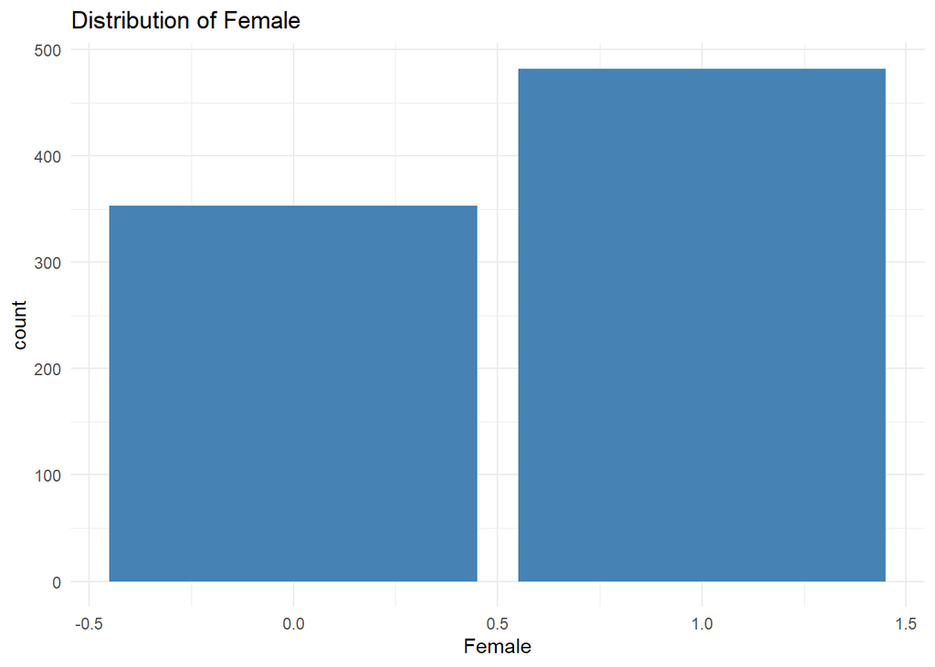

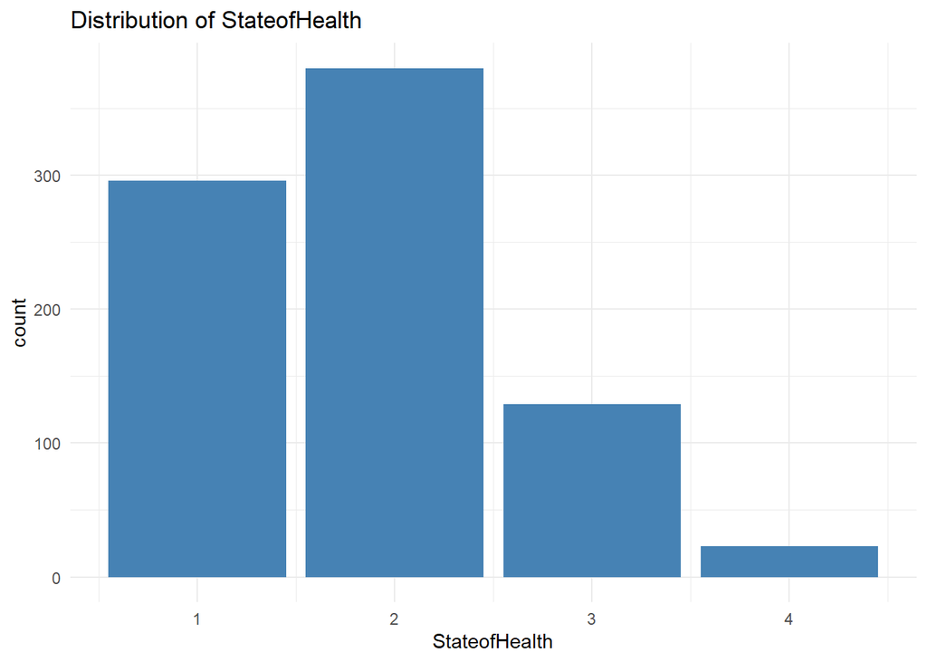

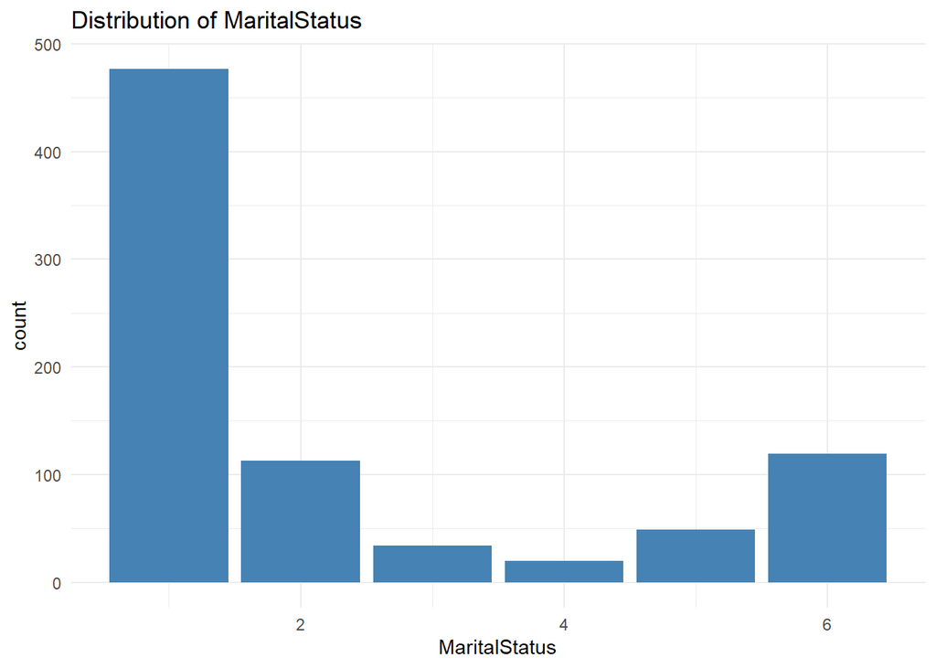

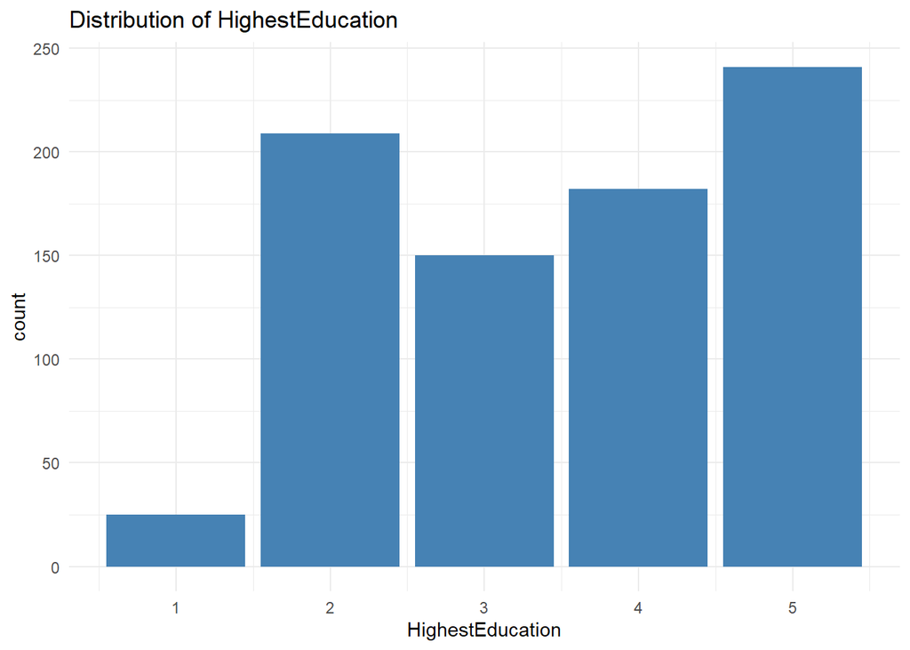

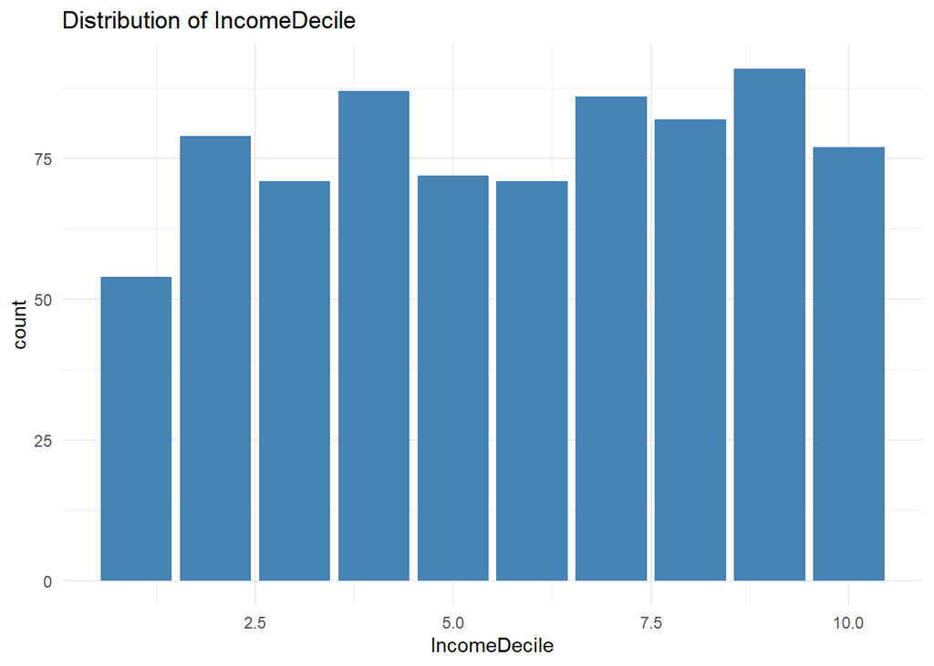

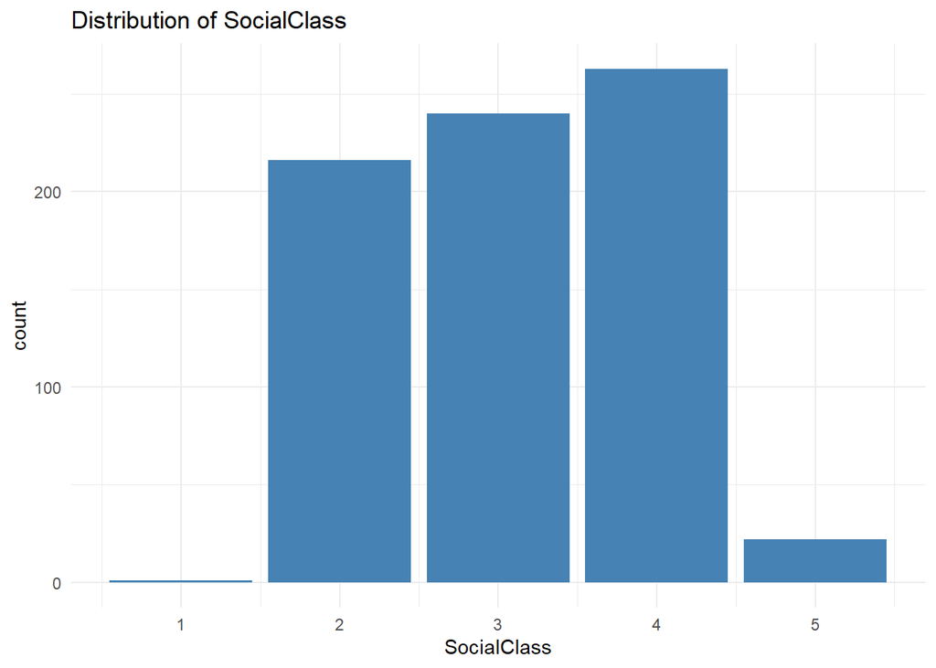

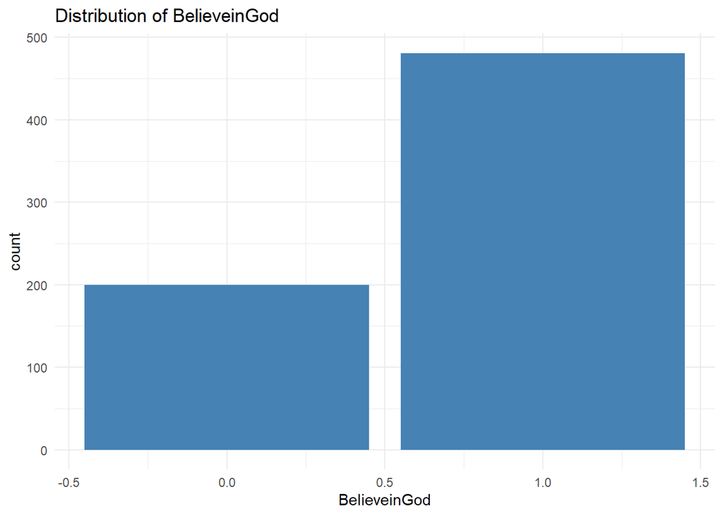

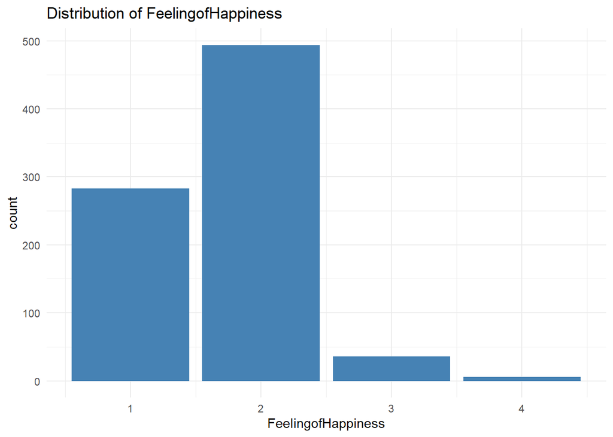

```r
# Bar plots for categorical variables
categorical_vars <- c("Female", "StateofHealth", "MaritalStatus", "HighestEducation",
                      "IncomeDecile", "SocialClass", "BelieveinGod", "FeelingofHappiness")

for (var in categorical_vars) {
  print(
    ggplot(wv, aes_string(x = var)) +
      geom_bar(fill = "steelblue") +
      theme_minimal() +
      ggtitle(paste("Distribution of", var))
  )
}
```

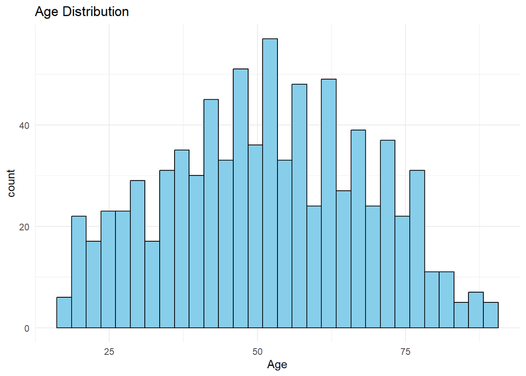

```r
# Histogram for Age and LifeSatisfaction
ggplot(wv, aes(x = Age)) +
  geom_histogram(bins = 30, fill = "skyblue", color = "black") +
  theme_minimal() +
  ggtitle("Age Distribution")
```

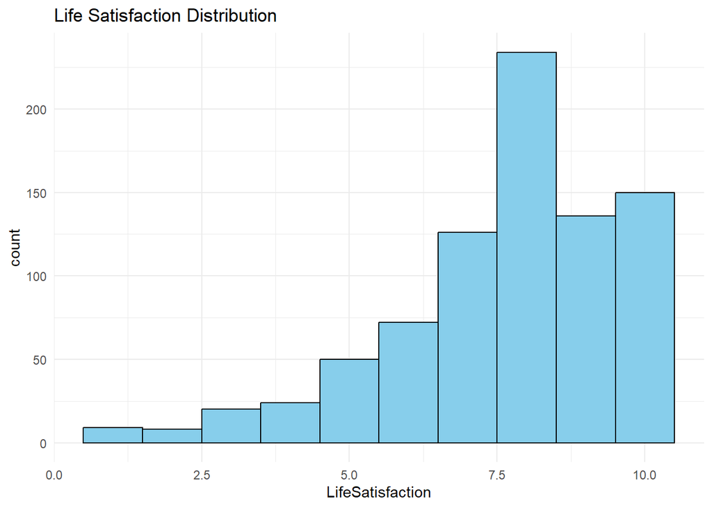

```r
ggplot(wv, aes(x = LifeSatisfaction)) +
  geom_histogram(bins = 10, fill = "skyblue", color = "black") +
  theme_minimal() +
  ggtitle("Life Satisfaction Distribution")
```

Bias in Survey Participation

Respondents to a values-based poll may differ significantly from the overall population.Individuals who are more socially involved, religious, or educated may be more likely to participate. This can bias the data, making it less representative of people who aren’t engaged in sociological or political issues. As a result, some groups (for example, those with lower incomes or less education) may be underrepresented.

**Variables with Most Missing Values**

```r
colSums(is.na(wv))
```

```
##             Female                Age      StateofHealth      MaritalStatus
##                  6                 13                 13                 29
##   HighestEducation   LifeSatisfaction       IncomeDecile        SocialClass
##                 34                 12                 71                 99
##       BelieveinGod FeelingofHappiness
##                160                 22
```

These 3 have the most missing values : - **BelieveinGod** (160 missing) - **SocialClass** (99 missing) - **IncomeDecile** (71 missing)

BelieveinGod - This could be because some people may not prefer to answer what their religion is or it should be because of lack of trust in god.

SocialClass - telling social status can be uncomfortable for many people and it could be bit condfusing since there is no defined thing for social status hence skipped responses

IncomeDecile: Income is often viewed as a sensitive data due to which people may not choose to disclose it.

### 3.2 Normalised dataset

Before performing cluster analysis, it is important to normalize the data because the variables we are using (such as Age and LifeSatisfaction) are measured on different scales. For example, Age can range from 18 to 90+, while LifeSatisfaction is from 1 to 10, and StateofHealth uses a 1–4 scale. If we do not normalize, variables with greater numeric ranges (such as Age) may dominate distance calculations in clustering like k-means and hierarchical clustering. Normalization guarantees that all variables contribute equally to the clustering process by placing them on the same scale (mean = 0, standard deviation = 1). In this step, we selected six variables relevant to clustering and used `scale()` to normalize them after removing rows with missing values.

```r
#selecting only numerical clustering variables
clustering_vars <- wv %>%
  select(Age, Female, MaritalStatus, StateofHealth, HighestEducation, LifeSatisfaction) %>%
  drop_na()

# Normalizing the variables
clustering_normalised <- as.data.frame(scale(clustering_vars))

head(clustering_normalised)
```

```
##          Age     Female MaritalStatus StateofHealth HighestEducation
## 1  1.0957236  0.8611325    -0.6716090     0.1926346        1.1858308
## 2 -1.3043877  0.8611325    -0.1374226     0.1926346       -0.4250290
## 3 -1.7244071  0.8611325    -0.6716090    -1.0770789        0.3804009
## 4 -1.4243932  0.8611325     1.9993229     0.1926346        0.3804009
## 5  0.6157014  0.8611325    -0.6716090    -1.0770789       -1.2304588
## 6 -1.5443988 -1.1597295    -0.1374226     2.7320616        0.3804009
##   LifeSatisfaction
## 1        0.1756701
## 2       -2.4149508
## 3        0.6937942
## 4        0.1756701
## 5        1.2119184
## 6       -2.4149508
```

### 3.3 Dendrogram

performed hierarchical clustering using complete linkage on the normalized dataset.The dendrogram depicts how observations are merged one by one based on similarity. searched the visual structure of the dendrogram for substantial vertical leaps between branches (indicating distinct groups). Based on this, we estimate that 4 clusters is an reasonable choice, given the branches separate quite clearly into four primary portions before merging higher up. This decision is fairly subjective, but it follows the typical technique employed in the clustering lecture and lab examples, in which the number of clusters was determined based on evident distinction in the tree structure.

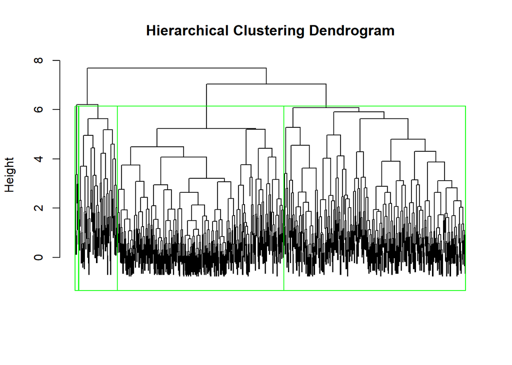

```r
#using normalized data and clustering_normalised is already a clean, scaled dataset

# Compute distance matrix
dist_matrix <- dist(clustering_normalised, method = "euclidean")

# Perform hierarchical clustering using complete linkage
hc_complete <- hclust(dist_matrix, method = "complete")

# Plot dendrogram
plot(hc_complete, labels = FALSE, main = "Hierarchical Clustering Dendrogram",
     xlab = "", sub = "", cex = 0.6)

#adding rectangle to visualize clusters
rect.hclust(hc_complete, k = 4, border = "green")
```

### 3.4 k-means

Applied k-means clustering to the normalized dataset using Euclidean distance and explored values of k from 1 to 10 to find the most appropriate number of clusters. First, applied the elbow method, which displays the total within-cluster sum of squares. The curve begins to flatten about k = 4, indicating that improvement decreases after that point. This is where the elbow appears, showing a nice blend of simplicity and dense clustering.

Next, used the average silhouette width to assess how effectively the clusters are separated. The highest silhouette value obtained at k = 8, but several other values (e.g., 4-7) achieved comparable scores.

Despite the silhouette plot showing k = 8, we picked k = 4 for interpretability and because the silhouette width at 4 clusters was still reasonably decent (~0.2), consistent with class advise that values over 0.2 are acceptable.

This process corresponds to the steps demonstrated in class with ‘fviz_nbclust()’, ‘fviz_silhouette()’, and visual interpretation of silhouette widths and cluster separation.

```r
# Load libraries
library(cluster)
library(factoextra)
```

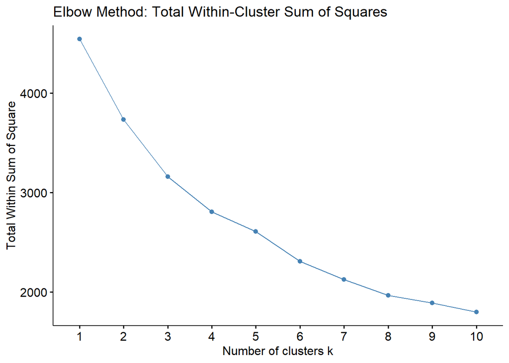

```r
# k-means clustering on the normalised data
set.seed(123)

# Elbow plot: Total within-cluster sum of squares
fviz_nbclust(clustering_normalised, kmeans, method = "wss") +
  ggtitle("Elbow Method: Total Within-Cluster Sum of Squares")
```

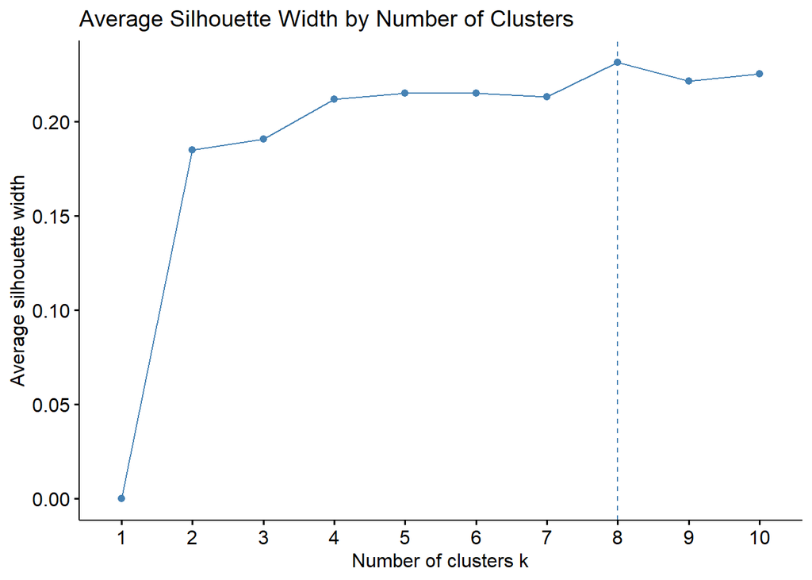

```r
# Silhouette method
fviz_nbclust(clustering_normalised, kmeans, method = "silhouette") +
  ggtitle("Average Silhouette Width by Number of Clusters")
```

```
##   cluster size ave.sil.width
## 1       1  228          0.19
## 2       2  282          0.29
## 3       3  112          0.19
## 4       4  136          0.07
```

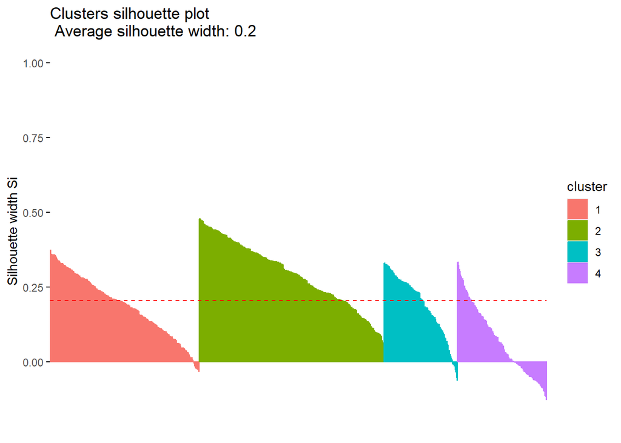

```r
# Run k-means with chosen k (e.g., k = 4, based on elbow/silhouette)
km4 <- kmeans(clustering_normalised, centers = 4, nstart = 25)

# 4. Silhouette plot
sil <- silhouette(km4$cluster, dist(clustering_normalised))
fviz_silhouette(sil)
```

### 3.5 Visualisation of heirarchical clustering

used fviz_cluster() to illustrate the results of hierarchical clustering using four clusters, each with complete linkage and normalized data.

This suggests that four clusters are a fair option. It is consistent with what we saw in the dendrogram and gives a good useful dataset segmentation; nevertheless, further refining (e.g., tweaking variables or comparing with k-means) may improve separation.

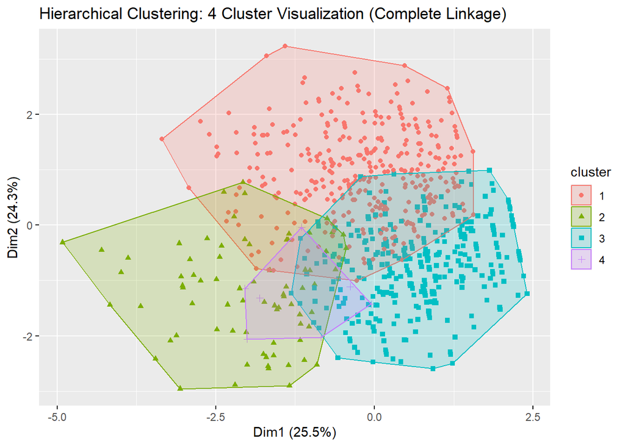

```r
# hierarchical clustering done earlier,from that cutting the tree into 4 clusters

hc_clusters <- cutree(hc_complete, k = 4)

# Add cluster labels to dataset
clustering_plot_data <- clustering_normalised %>%
  mutate(cluster = factor(hc_clusters))

# Plot clusters using PCA projection
fviz_cluster(list(data = clustering_normalised, cluster = hc_clusters),
             geom = "point",
             ellipse.type = "convex",
             show.clust.cent = FALSE,
             main = "Hierarchical Clustering: 4 Cluster Visualization (Complete Linkage)")
```

### 3.6 Visualisation of k-means clusters

These profiles offer useful insights into how different segments of people in the survey relate to age, education, health, and happiness.

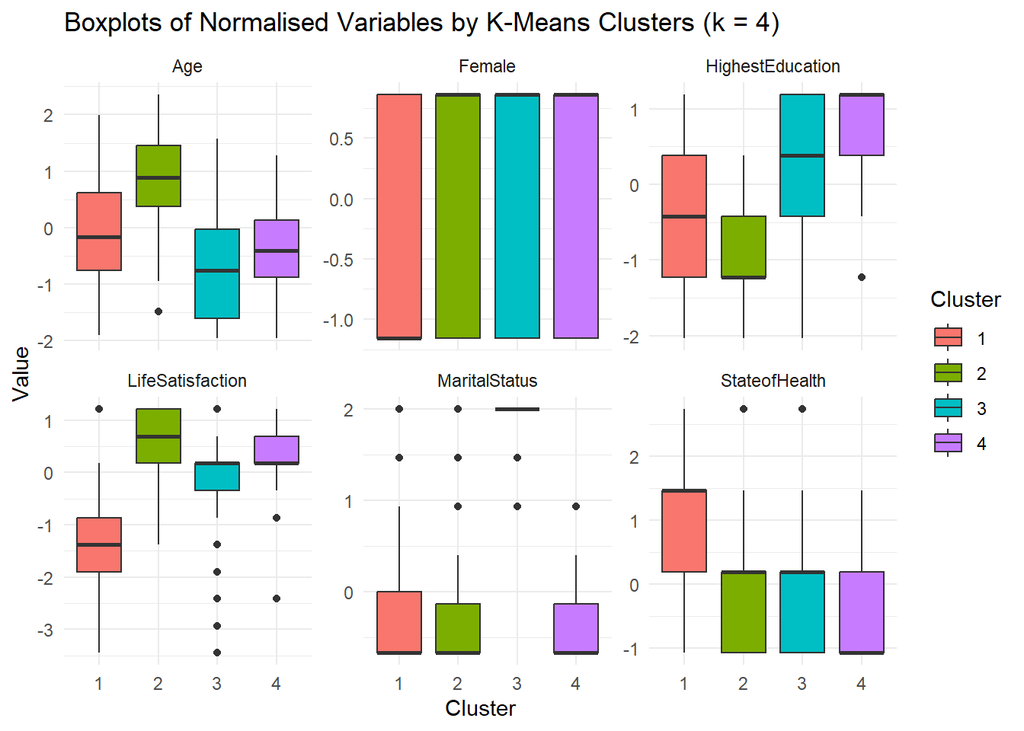

```r
# Run k-means again with k = 4
set.seed(123)
km4 <- kmeans(clustering_normalised, centers = 4, nstart = 25)

# Add cluster labels to the dataset
clustered_data <- clustering_normalised %>%
  mutate(Cluster = factor(km4$cluster))

# Convert to long format for easy plotting
library(tidyr)
long_data <- clustered_data %>%
  pivot_longer(cols = -Cluster, names_to = "Variable", values_to = "Value")

# Plot boxplots
ggplot(long_data, aes(x = Cluster, y = Value, fill = Cluster)) +
  geom_boxplot() +
  facet_wrap(~ Variable, scales = "free_y") +
  theme_minimal() +
  ggtitle("Boxplots of Normalised Variables by K-Means Clusters (k = 4)")
```

## Exercise 4

### 4.1 Frequency of colour use

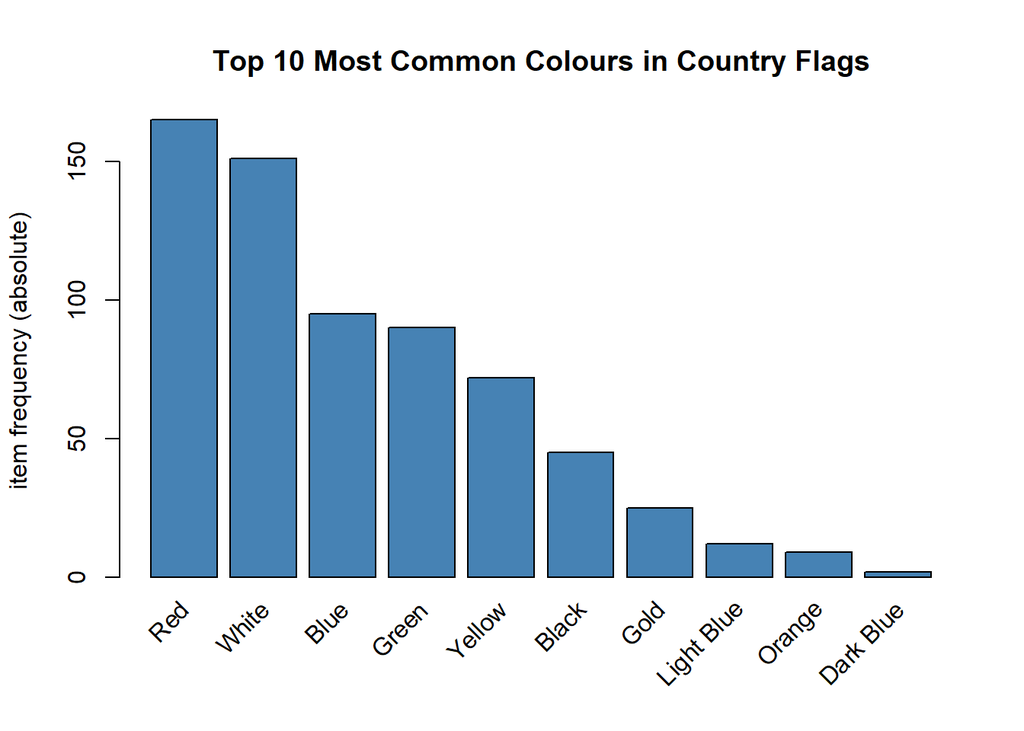

```r
# Load library
library(arules)
library(arulesViz)
# Plot item frequencies
itemFrequencyPlot(flags, topN = 10, type = "absolute", col = "steelblue",
                  main = "Top 10 Most Common Colours in Country Flags")
```

```r
# Get actual frequencies
colour_freq <- itemFrequency(flags, type = "absolute")
sort(colour_freq, decreasing = TRUE)[1:10]  # Show top 10 colours
```

```
##        Red      White       Blue      Green     Yellow      Black       Gold
##        165        151         95         90         72         45         25
## Light Blue     Orange  Dark Blue
##         12          9          2
```

### 4.2 Number of rules

```r
#Generate rules using the supplied support and confidence thresholds.
flag_rules <- apriori(flags, parameter = list(supp = 0.023, conf = 0.5))
```

```
## Apriori
##
## Parameter specification:
##  confidence minval smax arem  aval originalSupport maxtime support minlen
##         0.5    0.1    1 none FALSE            TRUE       5   0.023      1
##  maxlen target  ext
##      10  rules TRUE
##
## Algorithmic control:
##  filter tree heap memopt load sort verbose
##     0.1 TRUE TRUE  FALSE TRUE    2    TRUE
##
## Absolute minimum support count: 4
##
## set item appearances ...[0 item(s)] done [0.00s].
## set transactions ...[12 item(s), 212 transaction(s)] done [0.00s].
## sorting and recoding items ... [9 item(s)] done [0.00s].
## creating transaction tree ... done [0.00s].
## checking subsets of size 1 2 3 4 5 done [0.00s].
## writing ... [77 rule(s)] done [0.00s].
## creating S4 object  ... done [0.00s].
```

```r
# Count the number of rules
length(flag_rules)
```

```
## [1] 77
```

### 4.3 Highest support rules

he third rule with the highest support is:

{White} -> {Red} This means that if a country’s flag contains White, it is likely to also contain Red.

Support = 0.5566: Around 56% of all country flags include both White and Red.

Confidence = 0.7815: Among flags that include White, about 78% also include Red.

```r
# Sort rules by support in decreasing order
sorted_by_support <- sort(flag_rules, by = "support", decreasing = TRUE)

# View the top 5 rules
inspect(sorted_by_support[1:5])
```

```
##     lhs        rhs     support   confidence coverage  lift     count
## [1] {}      => {Red}   0.7783019 0.7783019  1.0000000 1.000000 165
## [2] {}      => {White} 0.7122642 0.7122642  1.0000000 1.000000 151
## [3] {White} => {Red}   0.5566038 0.7814570  0.7122642 1.004054 118
## [4] {Red}   => {White} 0.5566038 0.7151515  0.7783019 1.004054 118
## [5] {Blue}  => {White} 0.3349057 0.7473684  0.4481132 1.049285  71
```

```r
# Store the 3rd rule separately for analysis
rule3 <- sorted_by_support[3]
inspect(rule3)
```

```
##     lhs        rhs   support   confidence coverage  lift     count
## [1] {White} => {Red} 0.5566038 0.781457   0.7122642 1.004054 118
```

```r
quality(rule3)
```

```
##      support confidence  coverage     lift count
## 18 0.5566038   0.781457 0.7122642 1.004054   118
```

### 4.4 Lift greater than 2

Filtered the association rules to find those with lift larger than 2, which means that the colours in those rules are at least twice as likely to co-occur as they would be if they were independent.

These principles are especially relevant when advising on possible flag color combinations, such as when designing a new flag (e.g., Choiseul in the following question).

```r
# Subset rules with lift > 2
high_lift_rules <- subset(flag_rules, subset = lift > 2)

# Count how many rules
length(high_lift_rules)
```

```
## [1] 2
```

```r
# View the rules
inspect(high_lift_rules)
```

```
##     lhs                            rhs     support    confidence coverage
## [1] {Red, White, Yellow}        => {Black} 0.05660377 0.5454545  0.10377358
## [2] {Green, Red, White, Yellow} => {Black} 0.02830189 0.5000000  0.05660377
##     lift     count
## [1] 2.569697 12
## [2] 2.355556  6
```

### 4.5 Choiseul independence flag

The leaders of Choiseul want to create a new flag that must feature black. Based on our Apriori study of country flags, we have two proposals.

1. If there is going to be at least one other colour:

We examined all rules where Black appears in the LHS. The rule:

{Black} -> {Red} has the highest support (0.1745) among all such combinations.

This means that among all flags that have Black, Red is the most commonly co-occurring colour. Recommendation: Red is the most likely second colour to be chosen with Black.

2. If a 4-colour flag is to be chosen including Black, Blue, and Red:

We filtered rules where:LHS = {Black, Blue, Red}

From the output:

{Black, Blue, Red} -> {White} has support = 0.0236, meaning White is a common 4th colour when Black, Blue, and Red are present.

Recommendation: White is the most likely extra colour added to a flag already having Black, Blue, and Red.

Conclustion:

- If adding one colour to Black: Red is the most likely.
- If forming a four-colour flag with Black, Blue, and Red: White is the most probable fourth.

```r
# Filter rules where LHS contains "Black"
black_rules <- subset(flag_rules, subset = lhs %in% "Black")

# Sort by confidence
black_rules_sorted <- sort(black_rules, by = "confidence", decreasing = TRUE)

# View top suggestions
inspect(black_rules_sorted)
```

```
##      lhs                              rhs     support    confidence coverage
## [1]  {Black, Blue, Red}            => {White} 0.02358491 1.0000000  0.02358491
## [2]  {Black, Green, White, Yellow} => {Red}   0.02830189 1.0000000  0.02830189
## [3]  {Black, Green, White}         => {Red}   0.08018868 0.9444444  0.08490566
## [4]  {Black, White, Yellow}        => {Red}   0.05660377 0.9230769  0.06132075
## [5]  {Black, Green, Yellow}        => {Red}   0.04716981 0.9090909  0.05188679
## [6]  {Black, Green}                => {Red}   0.10849057 0.8846154  0.12264151
## [7]  {Black, White}                => {Red}   0.12735849 0.8709677  0.14622642
## [8]  {Black, Yellow}               => {Red}   0.08490566 0.8571429  0.09905660
## [9]  {Black}                       => {Red}   0.17452830 0.8222222  0.21226415
## [10] {Black, Blue}                 => {White} 0.03301887 0.7777778  0.04245283
## [11] {Black, Green, Red}           => {White} 0.08018868 0.7391304  0.10849057
## [12] {Black, Red}                  => {White} 0.12735849 0.7297297  0.17452830
## [13] {Black, Blue, White}          => {Red}   0.02358491 0.7142857  0.03301887
## [14] {Black, Green}                => {White} 0.08490566 0.6923077  0.12264151
```

[output cut: 41 more lines]